# P2_act_report (1)

## Report: act_report

**The aim of my visualisation**

My visualization was carried out to answer the following questions and communicate insights:

- Is there a relationshop between favourite count and retweet
- what are the most popular breeds
- What is the percentage of Dog breeds

Question 1

the dataset is gotten from twitter Api and as the name implies this dataset is about the ratings for dogs. so i used the bivariate data `favourite count and retweet` to see if there is a relationship and it turned out to be a **YES** because the scatter plot graph shows a positive relationship.

Question 3 i created a piechar to represent findings, it displayed the percentage of dog breeds in this dataset, which showed that doggo was the breed that appeared the most followed by floofer, pupper and puppo. although this is subject to change in the future as the rating of dogs continues but for now this is the percent.

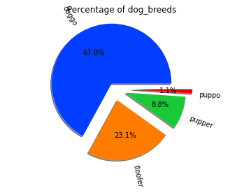

the image below was visualized to understand the relationship between retweet count and favourite count as opposed to the dog_breeds or dog stages as most people would like to name it.

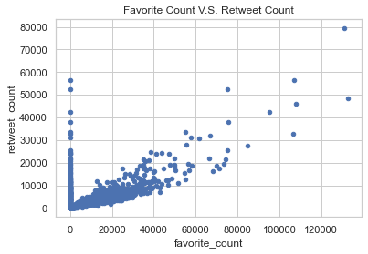